# Problem Statement:

You are a Data Scientist for a tourism company named "Visit with us". The Policy Maker of the company wants to enable and establish a viable business model to expand the customer base.

A viable business model is a central concept that helps you to understand the existing ways of doing the business and how to change the ways for the benefit of the tourism sector.

One of the ways to expand the customer base is to introduce a new offering of packages.

Currently, there are 5 types of packages the company is offering - Basic, Standard, Deluxe, Super Deluxe, King. Looking at the data of the last year, we observed that 18% of the customers purchased the packages.

However, the marketing cost was quite high because customers were contacted at random without looking at the available information.

The company is now planning to launch a new product i.e. Wellness Tourism Package. Wellness Tourism is defined as Travel that allows the traveler to maintain, enhance or kick-start a healthy lifestyle, and support or increase one's sense of well-being.

However, this time company wants to harness the available data of existing and potential customers to make the marketing expenditure more efficient.

You as a Data Scientist at "Visit with us" travel company have to analyze the customers' data and information to provide recommendations to the Policy Maker and Marketing Team and also build a model to predict the potential customer who is going to purchase the newly introduced travel package.

# Objective

To predict which customer is more likely to purchase the newly introduced travel package.

# Data Dictionary

**Customer details:**

1. CustomerID: Unique customer ID
2. ProdTaken: Whether the customer has purchased a package or not (0: No, 1: Yes)
3. Age: Age of customer
4. TypeofContact: How customer was contacted (Company Invited or Self Inquiry)
5. CityTier: City tier depends on the development of a city, population, facilities, and living standards. The categories are ordered i.e. Tier 1 > Tier 2 > Tier 3
6. Occupation: Occupation of customer
7. Gender: Gender of customer
8. NumberOfPersonVisiting: Total number of persons planning to take the trip with the customer
9. PreferredPropertyStar: Preferred hotel property rating by customer
10. MaritalStatus: Marital status of customer
11. NumberOfTrips: Average number of trips in a year by customer
12. Passport: The customer has a passport or not (0: No, 1: Yes)
13. OwnCar: Whether the customers own a car or not (0: No, 1: Yes)
14. NumberOfChildrenVisiting: Total number of children with age less than 5 planning to take the trip with the customer
15. Designation: Designation of the customer in the current organization
16. MonthlyIncome: Gross monthly income of the customer

**Customer interaction data:**

1. PitchSatisfactionScore: Sales pitch satisfaction score
2. ProductPitched: Product pitched by the salesperson
3. NumberOfFollowups: Total number of follow-ups has been done by the salesperson after the sales pitch
4. DurationOfPitch: Duration of the pitch by a salesperson to the customer

## Import libraries

```python
!pip install xgboost
```

```python
# Library to suppress warnings or deprecation notes
import warnings
warnings.filterwarnings('ignore')

# Libraries to help with reading and manipulating data
import numpy as np
import pandas as pd

# Libraries to help with data visualization
import matplotlib.pyplot as plt
%matplotlib inline
import seaborn as sns

# Libraries to split data, impute missing values
from sklearn.model_selection import train_test_split
from sklearn.impute import SimpleImputer
from sklearn.metrics import confusion_matrix,ConfusionMatrixDisplay,plot_confusion_matrix #to plot confusion matric

# Libraries to import decision tree classifier and different ensemble classifiers
from sklearn.ensemble import BaggingClassifier
from sklearn.ensemble import RandomForestClassifier
from sklearn.ensemble import AdaBoostClassifier, GradientBoostingClassifier
from xgboost import XGBClassifier
from sklearn.ensemble import StackingClassifier
from sklearn.tree import DecisionTreeClassifier
from sklearn import tree
from sklearn.linear_model import LogisticRegression
# Libtune to tune model, get different metric scores
from sklearn import metrics
from sklearn.metrics import confusion_matrix, classification_report, accuracy_score, precision_score, recall_score, f1_score, roc_auc_score
from sklearn.model_selection import GridSearchCV
```

## Read Dataset

```python
from google.colab import drive
drive.mount('/content/drive')
```

```python
tourismDf=pd.read_csv("/content/drive/MyDrive/Colab Notebooks/Ensemble Techniques/Project4/TourismData.csv")
```

```python
# copying data to another varaible to avoid any changes to original data
OriginalDf=tourismDf.copy()
```

#### Check for duplicates

```python
tourismDf.duplicated().any()
```

```
False
```

There are no duplicates in the dataset.

### View the first and last 5 rows of the dataset.

```python
tourismDf.head()
```

|  | CustomerID | ProdTaken | Age | TypeofContact | CityTier | DurationOfPitch | Occupation | Gender | NumberOfPersonVisiting | NumberOfFollowups | ProductPitched | PreferredPropertyStar | MaritalStatus | NumberOfTrips | Passport | PitchSatisfactionScore | OwnCar | NumberOfChildrenVisiting | Designation | MonthlyIncome |
| --- | --- | --- | --- | --- | --- | --- | --- | --- | --- | --- | --- | --- | --- | --- | --- | --- | --- | --- | --- | --- |
| 0 | 200000 | 1 | 41.0 | Self Enquiry | 3 | 6.0 | Salaried | Female | 3 | 3.0 | Deluxe | 3.0 | Single | 1.0 | 1 | 2 | 1 | 0.0 | Manager | 20993.0 |
| 1 | 200001 | 0 | 49.0 | Company Invited | 1 | 14.0 | Salaried | Male | 3 | 4.0 | Deluxe | 4.0 | Divorced | 2.0 | 0 | 3 | 1 | 2.0 | Manager | 20130.0 |
| 2 | 200002 | 1 | 37.0 | Self Enquiry | 1 | 8.0 | Free Lancer | Male | 3 | 4.0 | Basic | 3.0 | Single | 7.0 | 1 | 3 | 0 | 0.0 | Executive | 17090.0 |
| 3 | 200003 | 0 | 33.0 | Company Invited | 1 | 9.0 | Salaried | Female | 2 | 3.0 | Basic | 3.0 | Divorced | 2.0 | 1 | 5 | 1 | 1.0 | Executive | 17909.0 |
| 4 | 200004 | 0 | NaN | Self Enquiry | 1 | 8.0 | Small Business | Male | 2 | 3.0 | Basic | 4.0 | Divorced | 1.0 | 0 | 5 | 1 | 0.0 | Executive | 18468.0 |

```python
tourismDf.tail()
```

|  | CustomerID | ProdTaken | Age | TypeofContact | CityTier | DurationOfPitch | Occupation | Gender | NumberOfPersonVisiting | NumberOfFollowups | ProductPitched | PreferredPropertyStar | MaritalStatus | NumberOfTrips | Passport | PitchSatisfactionScore | OwnCar | NumberOfChildrenVisiting | Designation | MonthlyIncome |
| --- | --- | --- | --- | --- | --- | --- | --- | --- | --- | --- | --- | --- | --- | --- | --- | --- | --- | --- | --- | --- |
| 4883 | 204883 | 1 | 49.0 | Self Enquiry | 3 | 9.0 | Small Business | Male | 3 | 5.0 | Deluxe | 4.0 | Unmarried | 2.0 | 1 | 1 | 1 | 1.0 | Manager | 26576.0 |
| 4884 | 204884 | 1 | 28.0 | Company Invited | 1 | 31.0 | Salaried | Male | 4 | 5.0 | Basic | 3.0 | Single | 3.0 | 1 | 3 | 1 | 2.0 | Executive | 21212.0 |
| 4885 | 204885 | 1 | 52.0 | Self Enquiry | 3 | 17.0 | Salaried | Female | 4 | 4.0 | Standard | 4.0 | Married | 7.0 | 0 | 1 | 1 | 3.0 | Senior Manager | 31820.0 |
| 4886 | 204886 | 1 | 19.0 | Self Enquiry | 3 | 16.0 | Small Business | Male | 3 | 4.0 | Basic | 3.0 | Single | 3.0 | 0 | 5 | 0 | 2.0 | Executive | 20289.0 |
| 4887 | 204887 | 1 | 36.0 | Self Enquiry | 1 | 14.0 | Salaried | Male | 4 | 4.0 | Basic | 4.0 | Unmarried | 3.0 | 1 | 3 | 1 | 2.0 | Executive | 24041.0 |

**Observations:**

`Age`, `DurationOfPitch`, `NUmberOfFollowups`, `PreferredPropertyStar`,`NumberOfTrips`,`NumberOfChildrenVisiting` are are floating point values, it might make the interpretation easier if we change them to integer type. There will be some reduction in space too.

### Understand the shape of the dataset.

```python
# Get the number of rows and columns
rows = len(tourismDf.axes[0])
cols = len(tourismDf.axes[1])

# Print the number of rows and columns
print("Number of Rows: " + str(rows))
print("Number of Columns: " + str(cols))
```

```
Number of Rows: 4888
Number of Columns: 20
```

### Check the data types of the columns for the dataset.

```python
tourismDf.info()
```

```
<class 'pandas.core.frame.DataFrame'>
RangeIndex: 4888 entries, 0 to 4887
Data columns (total 20 columns):
 #   Column                    Non-Null Count  Dtype
---  ------                    --------------  -----
 0   CustomerID                4888 non-null   int64
 1   ProdTaken                 4888 non-null   int64
 2   Age                       4662 non-null   float64
 3   TypeofContact             4863 non-null   object
 4   CityTier                  4888 non-null   int64
 5   DurationOfPitch           4637 non-null   float64
 6   Occupation                4888 non-null   object
 7   Gender                    4888 non-null   object
 8   NumberOfPersonVisiting    4888 non-null   int64
 9   NumberOfFollowups         4843 non-null   float64
 10  ProductPitched            4888 non-null   object
 11  PreferredPropertyStar     4862 non-null   float64
 12  MaritalStatus             4888 non-null   object
 13  NumberOfTrips             4748 non-null   float64
 14  Passport                  4888 non-null   int64
 15  PitchSatisfactionScore    4888 non-null   int64
 16  OwnCar                    4888 non-null   int64
 17  NumberOfChildrenVisiting  4822 non-null   float64
 18  Designation               4888 non-null   object
 19  MonthlyIncome             4655 non-null   float64
dtypes: float64(7), int64(7), object(6)
memory usage: 763.9+ KB
```

**Observations:**

- We can see that there are total of 20 columns and 4888 rows in the dataset.
- The data type of the columns are either integer, float or object type.
- The are a few columns with null values in this dataset. We can further check using `isna()` method.
- We can convert the object data type to categorical type. `converting "objects" to "category" reduces the data space required to store the dataframe`

```python
tourismDf.columns[tourismDf.isnull().any()]
```

```
Index(['Age', 'TypeofContact', 'DurationOfPitch', 'NumberOfFollowups',
       'PreferredPropertyStar', 'NumberOfTrips', 'NumberOfChildrenVisiting',
       'MonthlyIncome'],
      dtype='object')
```

The columns `Age`, `TypeofContact`, `DurationOfPitch`, `NumberOfFollowups`, `PreferredPropertyStar`, `NumberOfTrips`, `NumberOfChildrenVisiting`, `MonthlyIncome` have null values.

Let us handle them in the next section.

`CustomerID` column does not have any significance on data analysis, so we can drop this column.

```python
 tourismDf.drop('CustomerID', axis=1, inplace=True)
```

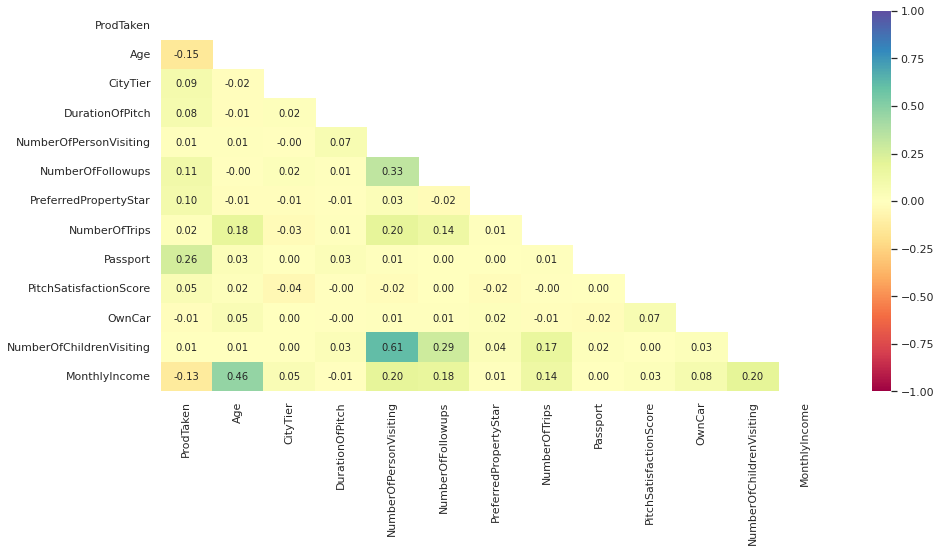

```python
plt.figure(figsize=(15, 7))
# sns.heatmap(tourismDf.corr(), annot=True, vmin=-1, vmax=1, fmt=".2f")
# plt.show()

corr= tourismDf.corr()

# Getting the Upper Triangle of the co-relation matrix
matrix = np.triu(corr)

# using the upper triangle matrix as mask
sns.heatmap(corr, annot=True,vmin=-1, vmax=1, fmt=".2f", mask=matrix, cmap='Spectral')
plt.show()
```

*Observations:*

- `ProductTaken` has a positive correlation with `Passport`
- `Age` has a strong correlation with `MonthlyIncome`
- `NumberOfPersonsVisiting` seems to have a strong correlation with `NumberOfChildrenVisiting` and `NumberOfFollowups` and slight correlation with `NumberOfTrips` and `MonthlyIncome`

## Fixing the data types

```python
tourismDf.info()
```

```
<class 'pandas.core.frame.DataFrame'>
RangeIndex: 4888 entries, 0 to 4887
Data columns (total 19 columns):
 #   Column                    Non-Null Count  Dtype
---  ------                    --------------  -----
 0   ProdTaken                 4888 non-null   int64
 1   Age                       4662 non-null   float64
 2   TypeofContact             4863 non-null   object
 3   CityTier                  4888 non-null   int64
 4   DurationOfPitch           4637 non-null   float64
 5   Occupation                4888 non-null   object
 6   Gender                    4888 non-null   object
 7   NumberOfPersonVisiting    4888 non-null   int64
 8   NumberOfFollowups         4843 non-null   float64
 9   ProductPitched            4888 non-null   object
 10  PreferredPropertyStar     4862 non-null   float64
 11  MaritalStatus             4888 non-null   object
 12  NumberOfTrips             4748 non-null   float64
 13  Passport                  4888 non-null   int64
 14  PitchSatisfactionScore    4888 non-null   int64
 15  OwnCar                    4888 non-null   int64
 16  NumberOfChildrenVisiting  4822 non-null   float64
 17  Designation               4888 non-null   object
 18  MonthlyIncome             4655 non-null   float64
dtypes: float64(7), int64(6), object(6)
memory usage: 725.7+ KB
```

#### Convert the data type of categorical columns from object to category

```python
for i in tourismDf.select_dtypes(['object']).columns:
    tourismDf[i] = tourismDf[i].astype('category')
```

```python
tourismDf.memory_usage().sum()/1024
```

```
526.1640625
```

We can see that the memory usage has decreased from `763.9 KB to 526.2 KB`, this technique is generally useful for bigger datasets.

### Check the unique values of categorical field

#### Passport Field

```python
tourismDf.Passport.unique()
```

```
array([1, 0])
```

Passport field has two distinct values 0 and 1, and there are no missing values, so this can be converted from integer to a categorical field.

```python
tourismDf.Passport = tourismDf.Passport.astype('category')
```

#### OwnCar Field

Similarly `OwnCar` field has two distinct values 0 and 1, so this can be converted into a categorical field.

```python
tourismDf.OwnCar.unique()
```

```
array([1, 0])
```

```python
tourismDf.OwnCar = tourismDf.OwnCar.astype('category')
```

#### PitchSatisfactionScore Field

```python
tourismDf.PitchSatisfactionScore.unique()
```

```
array([2, 3, 5, 4, 1])
```

Similarly `PitchSatisfactionScore` has finite set of values, we can convert it from integer to categorical type.

```python
tourismDf.PitchSatisfactionScore = tourismDf.PitchSatisfactionScore.astype('category')
```

#### Gender Field - Text Processing

```python
tourismDf.Gender.unique()
```

```
['Female', 'Male', 'Fe Male']
Categories (3, object): ['Female', 'Male', 'Fe Male']
```

```python
tourismDf.Gender = tourismDf.Gender.str.replace(' ','')
tourismDf.Gender = tourismDf.Gender.str.replace('FeMale','Female')
tourismDf.Gender.unique()
```

```
array(['Female', 'Male'], dtype=object)
```

```python
tourismDf.Gender = tourismDf.Gender.astype('category')
```

Text processing is required on the Gender field as there are spaces and mix of upper case and lower case characters for Female gender.

#### Occupation Field

```python
tourismDf.Occupation.unique()
```

```
['Salaried', 'Free Lancer', 'Small Business', 'Large Business']
Categories (4, object): ['Salaried', 'Free Lancer', 'Small Business', 'Large Business']
```

**This data looks good, so we can leave it as it is.**

#### ProductPitched field

```python
tourismDf.ProductPitched.unique()
```

```
['Deluxe', 'Basic', 'Standard', 'Super Deluxe', 'King']
Categories (5, object): ['Deluxe', 'Basic', 'Standard', 'Super Deluxe', 'King']
```

#### MaritalStatus Field

```python
tourismDf.MaritalStatus.unique()
```

```
['Single', 'Divorced', 'Married', 'Unmarried']
Categories (4, object): ['Single', 'Divorced', 'Married', 'Unmarried']
```

#### Designation Field

```python
tourismDf.Designation.unique()
```

```
['Manager', 'Executive', 'Senior Manager', 'AVP', 'VP']
Categories (5, object): ['Manager', 'Executive', 'Senior Manager', 'AVP', 'VP']
```

#### TypeOfContact Field

```python
tourismDf.TypeofContact.unique()
```

```
['Self Enquiry', 'Company Invited', NaN]
Categories (2, object): ['Self Enquiry', 'Company Invited']
```

#### CityTier Field

```python
tourismDf.CityTier.unique()
```

```
array([3, 1, 2])
```

```python
tourismDf.CityTier = tourismDf.CityTier.astype('category')
```

#### NumberOfFollowups Field

```python
tourismDf.NumberOfFollowups.unique()
```

```
array([ 3.,  4.,  2.,  5., nan,  1.,  6.])
```

#### PreferredPropertyStar Field

```python
tourismDf.PreferredPropertyStar.unique()
```

```
array([ 3.,  4.,  5., nan])
```

```python
tourismDf.PreferredPropertyStar = tourismDf.PreferredPropertyStar.astype('category')
```

**Observations:**

- Except `Gender`,`TypeOfContact`,`NumberOfFollowups` and `PreferredPropertyStar` field, the data looks good on all other fields.
- Extraspace within the word and mix of upper and lower case has been corrected on the Gender Field.
- We can treat the missing values in the `TypeOfContact`,`NumberOfFollowups` and `PreferredPropertyStar` field later.
- Now, all the categorical fields have unique values.

### Summary of the dataset.

```python
tourismDf.describe().T
```

|  | count | mean | std | min | 25% | 50% | 75% | max |
| --- | --- | --- | --- | --- | --- | --- | --- | --- |
| ProdTaken | 4888.0 | 0.188216 | 0.390925 | 0.0 | 0.0 | 0.0 | 0.0 | 1.0 |
| Age | 4662.0 | 37.622265 | 9.316387 | 18.0 | 31.0 | 36.0 | 44.0 | 61.0 |
| DurationOfPitch | 4637.0 | 15.490835 | 8.519643 | 5.0 | 9.0 | 13.0 | 20.0 | 127.0 |
| NumberOfPersonVisiting | 4888.0 | 2.905074 | 0.724891 | 1.0 | 2.0 | 3.0 | 3.0 | 5.0 |
| NumberOfFollowups | 4843.0 | 3.708445 | 1.002509 | 1.0 | 3.0 | 4.0 | 4.0 | 6.0 |
| NumberOfTrips | 4748.0 | 3.236521 | 1.849019 | 1.0 | 2.0 | 3.0 | 4.0 | 22.0 |
| NumberOfChildrenVisiting | 4822.0 | 1.187267 | 0.857861 | 0.0 | 1.0 | 1.0 | 2.0 | 3.0 |
| MonthlyIncome | 4655.0 | 23619.853491 | 5380.698361 | 1000.0 | 20346.0 | 22347.0 | 25571.0 | 98678.0 |

**Observations on continuous values:**

- Median `Age` of the people in this data set is 36 years, ranging from people as young as 18 years and as old as 61 years.
- `DurationOfPitch` has a minimum value of 5 and a max value of 127, wich clearly indicates there are outliers in the data. We can futher investigate this data.
- `NumberOfPersonVisiting` range from 1 to 5, with the median value being 3.
- `NumberOfChildrenVisiting` number of children less than 5 years old who are visiting the trip with the customer range from 0 to 3 with the median value being 1. Maximum number of children under 5 who visit the trip with cutomer is 3.
- `MonhlyIncome` the average monthly income of the customers is 23K per month and the median income is 22K where as max monthly income is 98K and the min monthly income is 1K. It is possible there are outliers in this data, let us check further in our next steps and see how we can treat them.

```python
tourismDf.describe(include=['category']).T
```

|  | count | unique | top | freq |
| --- | --- | --- | --- | --- |
| TypeofContact | 4863 | 2 | Self Enquiry | 3444 |
| CityTier | 4888 | 3 | 1 | 3190 |
| Occupation | 4888 | 4 | Salaried | 2368 |
| Gender | 4888 | 2 | Male | 2916 |
| ProductPitched | 4888 | 5 | Basic | 1842 |
| PreferredPropertyStar | 4862 | 3 | 3 | 2993 |
| MaritalStatus | 4888 | 4 | Married | 2340 |
| Passport | 4888 | 2 | 0 | 3466 |
| PitchSatisfactionScore | 4888 | 5 | 3 | 1478 |
| OwnCar | 4888 | 2 | 1 | 3032 |
| Designation | 4888 | 5 | Executive | 1842 |

```python
tourismDf.Designation.unique()
```

```
['Manager', 'Executive', 'Senior Manager', 'AVP', 'VP']
Categories (5, object): ['Manager', 'Executive', 'Senior Manager', 'AVP', 'VP']
```

**Observations on categorical values:**

```python
tourismDf.corr()
```

|  | ProdTaken | Age | DurationOfPitch | NumberOfPersonVisiting | NumberOfFollowups | NumberOfTrips | NumberOfChildrenVisiting | MonthlyIncome |
| --- | --- | --- | --- | --- | --- | --- | --- | --- |
| ProdTaken | 1.000000 | -0.147254 | 0.078257 | 0.009627 | 0.112171 | 0.018898 | 0.007421 | -0.130585 |
| Age | -0.147254 | 1.000000 | -0.012063 | 0.011621 | -0.002577 | 0.184905 | 0.007370 | 0.464869 |
| DurationOfPitch | 0.078257 | -0.012063 | 1.000000 | 0.065141 | 0.009434 | 0.009715 | 0.031408 | -0.006252 |
| NumberOfPersonVisiting | 0.009627 | 0.011621 | 0.065141 | 1.000000 | 0.328569 | 0.195223 | 0.610621 | 0.195134 |
| NumberOfFollowups | 0.112171 | -0.002577 | 0.009434 | 0.328569 | 1.000000 | 0.139517 | 0.286425 | 0.176503 |
| NumberOfTrips | 0.018898 | 0.184905 | 0.009715 | 0.195223 | 0.139517 | 1.000000 | 0.168795 | 0.139105 |
| NumberOfChildrenVisiting | 0.007421 | 0.007370 | 0.031408 | 0.610621 | 0.286425 | 0.168795 | 1.000000 | 0.201643 |
| MonthlyIncome | -0.130585 | 0.464869 | -0.006252 | 0.195134 | 0.176503 | 0.139105 | 0.201643 | 1.000000 |

**Observations on correlation of data:**

- `Age` and `MonthlyIncome` are negatively correlated with Product taken.
- `Durationofpitch` has a slightlly positive correlation with ProductTaken, `NUmberOfPersonVisiting` and `NumberOfChildrenVisiting`.
- `MonthlyIncome` has a strong correlation with Age and slight positive correlation with `NumberOfPersonVisiting`, `NumberOfTrips` and `NumberOfChildrenVisiting`.

# Exploratory Data Analysis

## Univariate Analysis

#### Functions for creating graphs and charts

```python
# While doing uni-variate analysis of numerical variables we want to study their central tendency
# and dispersion.
# Let us write a function that will help us create boxplot and histogram for any input numerical
# variable.
# This function takes the numerical column as the input and returns the boxplots
# and histograms for the variable.
# Let us see if this help us write faster and cleaner code.
# function to plot a boxplot and a histogram along the same scale.
def histogram_boxplot(data, feature, figsize=(12, 7), kde=False, bins=None):
    """
    Boxplot and histogram combined

    data: dataframe
    feature: dataframe column
    figsize: size of figure (default (12,7))
    kde: whether to show the density curve (default False)
    bins: number of bins for histogram (default None)
    """
    f2, (ax_box2, ax_hist2) = plt.subplots(
        nrows=2,  # Number of rows of the subplot grid= 2
        sharex=True,  # x-axis will be shared among all subplots
        gridspec_kw={"height_ratios": (0.25, 0.75)},
        figsize=figsize,
    )  # creating the 2 subplots
    sns.boxplot(
        data=data, x=feature, ax=ax_box2, showmeans=True, color="violet"
    )  # boxplot will be created and a star will indicate the mean value of the column
    sns.histplot(
        data=data, x=feature, kde=kde, ax=ax_hist2, bins=bins, palette="winter"
    ) if bins else sns.histplot(
        data=data, x=feature, kde=kde, ax=ax_hist2
    )  # For histogram
    ax_hist2.axvline(
        data[feature].mean(), color="green", linestyle="--"
    )  # Add mean to the histogram
    ax_hist2.axvline(
        data[feature].median(), color="black", linestyle="-"
    )  # Add median to the histogram
```

```python
# function to create labeled barplots
def labeled_barplot(data, feature, perc=False, n=None):
    """
    Barplot with percentage at the top

    data: dataframe
    feature: dataframe column
    perc: whether to display percentages instead of count (default is False)
    n: displays the top n category levels (default is None, i.e., display all levels)
    """

    total = len(data[feature])  # length of the column
    count = data[feature].nunique()
    if n is None:
        plt.figure(figsize=(count + 2, 6))
    else:
        plt.figure(figsize=(n + 2, 6))

    plt.xticks(rotation=90, fontsize=15)
    ax = sns.countplot(
        data=data,
        x=feature,
        palette="Paired",
        order=data[feature].value_counts().index[:n].sort_values(),
    )

    for p in ax.patches:
        if perc == True:
            label = "{:.1f}%".format(
                100 * p.get_height() / total
            )  # percentage of each class of the category
        else:
            label = p.get_height()  # count of each level of the category

        x = p.get_x() + p.get_width() / 2  # width of the plot
        y = p.get_height()  # height of the plot

        ax.annotate(
            label,
            (x, y),
            ha="center",
            va="center",
            size=12,
            xytext=(0, 5),
            textcoords="offset points",
        )  # annotate the percentage

    plt.show()  # show the plot
```

#### Observations on ProdTaken

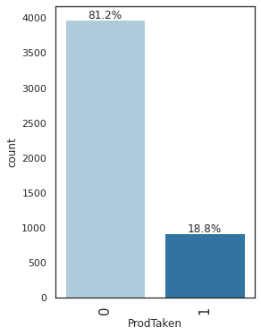

```python
labeled_barplot(tourismDf,'ProdTaken', perc=True)
```

**18.8% of the customers have purchased a travel package from the company 'Visit with us' while 81.2% of them have not purchased the travel package.**

### Observations on Age

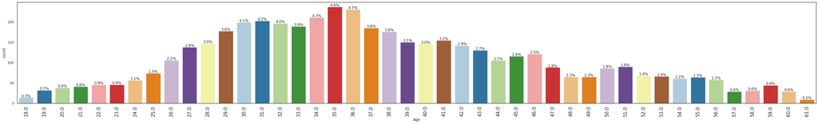

```python
labeled_barplot(tourismDf,'Age', perc=True)
```

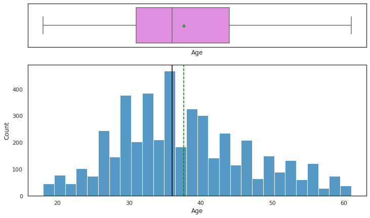

```python
histogram_boxplot(tourismDf,'Age')
```

- Median Age of the customer is slightly less than the mean and the data is slightly skewed to the right.
- Median `Age` of the people in this data set is 36 years, ranging from people as young as 18 years and as old as 61 years.

### Observations on TypeofContact

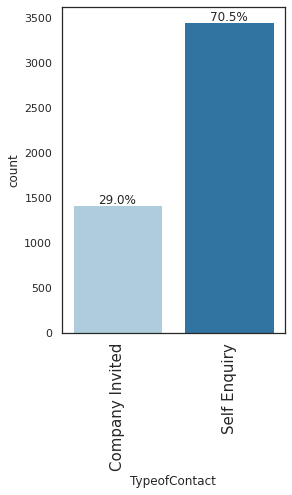

```python
labeled_barplot(tourismDf,'TypeofContact', perc=True)
```

- 70.5% of the customers came through self enquiry where are 29.0% of them are company invited.

### Observations on CityTier

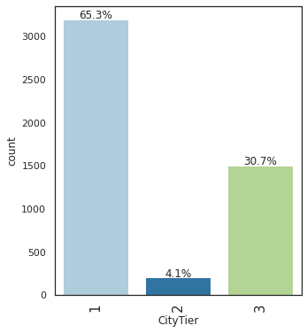

```python
labeled_barplot(tourismDf,'CityTier', perc=True)
```

- 65.3% of the customers come from Tier 1 cities, 30.7% of them come from Tier 3 cities and 4.1% of them are from Tier 2 cities.

### Observations on DurationOfPitch

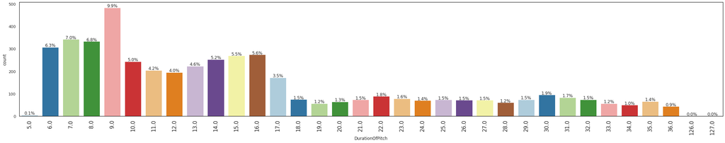

```python
labeled_barplot(tourismDf,'DurationOfPitch', perc=True)
```

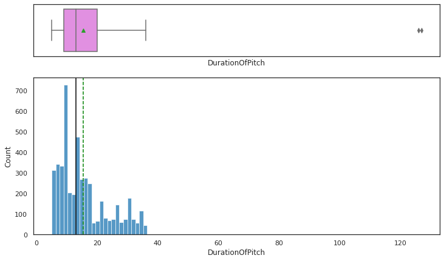

```python
histogram_boxplot(tourismDf,'DurationOfPitch')
```

**Observations:**

- `DurationOfPitch` is skewed more to the right, but there are only a few outliers.
- Duration will vary depending on the customer so it is perfectly fine not to treat this outlier. Also, since we are dealing with only a few records, in realtime there will be millions of records and the data will look more balanced when there are more records.

### Observations on Occupation

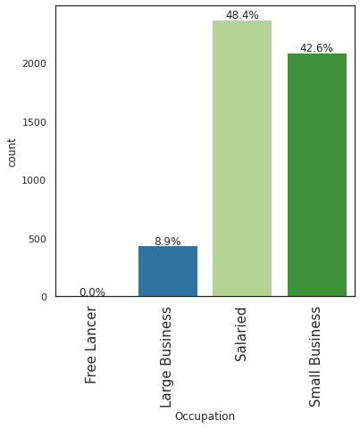

```python
labeled_barplot(tourismDf,'Occupation', perc=True)
```

```python
tourismDf.Occupation.value_counts()
```

```
Salaried          2368
Small Business    2084
Large Business     434
Free Lancer          2
Name: Occupation, dtype: int64
```

- 48.4% of the customers are Salaried.
- 42.6% of them are Small Business owners.
- 8.9% of them are Large Business Owners.
- 2 of them out of 4888 obesrved customers are Freelancers, so it is hard to predict, customers of this category in this data set, it can be considered as outlier, but since the decission tree does not have any impact due to this I am choosing to leave it as it is.
- In production data where the number of samples are high, it may be good to consider having this value.

### Observations on Gender

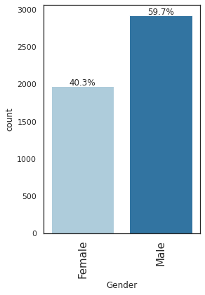

```python
labeled_barplot(tourismDf,'Gender', perc=True)
```

- 59.7% of them are Male customers
- 40.3% of them are female customers.

### Observations on NumberOfPersonVisiting

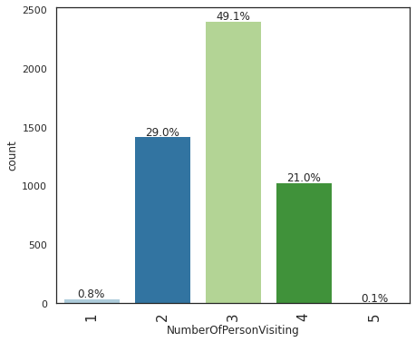

```python
labeled_barplot(tourismDf,'NumberOfPersonVisiting', perc=True)
```

- 49.1% of the customers plan to take the trip as a group of 3 people
- 21% of them plan to take the trip as a group of 4 people.
- 29% of them plan to take the trip as couple and .8% of them plan to go single.

### Observations on NumberOfFollowups

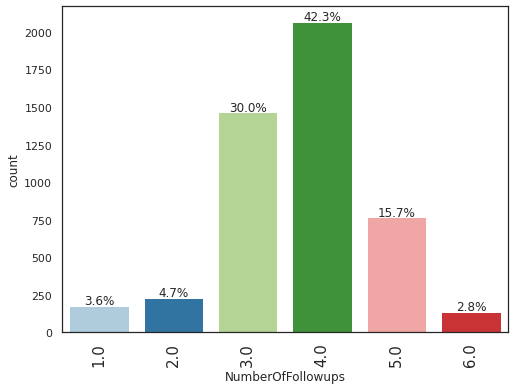

```python
labeled_barplot(tourismDf,'NumberOfFollowups', perc=True)
```

**Observations:**

The highest number of followups is 4.0 followed by 3.0.

### Observations on ProductPitched

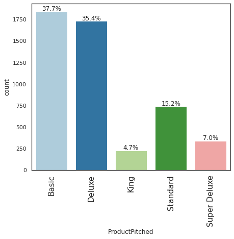

```python
labeled_barplot(tourismDf,'ProductPitched',perc=True)
```

**Observations:**

1. Basic(37.7%) and Deluxe(35.4%) are the most popular travel packages.
2. The next slightly popular one is the Standard Travel package at 15.2%.

### Observations on PreferredPropertyStar

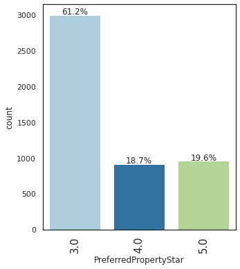

```python
labeled_barplot(tourismDf,'PreferredPropertyStar',perc=True)
```

**Observations:**

61.2% customers prefer a three star hotel rating compared to four (18.7%) and five (19.6%) star rating hotels

### Observations on MaritalStatus

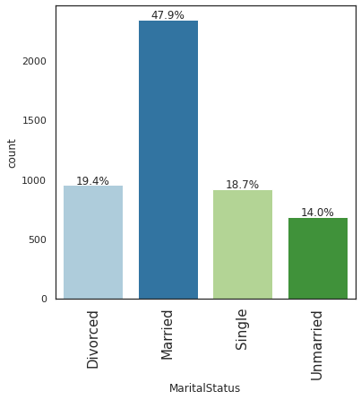

```python
labeled_barplot(tourismDf,'MaritalStatus', perc=True)
```

**Observations:**

1. Married customers form the bulk of the data at 47.9%.
2. Divorced (19.4%) and Single (18.7%) coming in close at second and third place.
3. Unmarried customers with partners form 14% of the data.

### Observations on NumberOfTrips

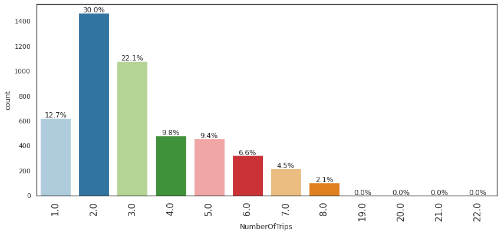

```python
labeled_barplot(tourismDf,'NumberOfTrips', perc=True)
```

**Observations:**

1. NumberofTrips is right-skewed a little and majority of the customers seem to take at least 2 trips per year.
2. We also see very few outliers in the higher end.

```python
tourismDf.NumberOfTrips.value_counts()
```

```
2.0     1464
3.0     1079
1.0      620
4.0      478
5.0      458
6.0      322
7.0      218
8.0      105
21.0       1
19.0       1
22.0       1
20.0       1
Name: NumberOfTrips, dtype: int64
```

### Observations on Passport

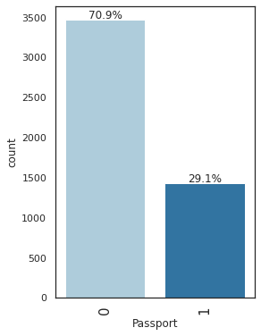

```python
labeled_barplot(tourismDf,'Passport', perc=True)
```

**Observations:**

Only 29.1% of customers have a passport

### Observations on PitchSatisfactionScore

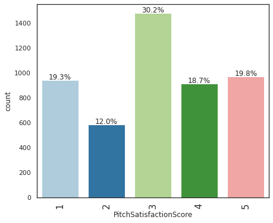

```python
labeled_barplot(tourismDf,'PitchSatisfactionScore', perc=True)
```

**Observations:**

1. Only 30.2% of customers rated the Sales Pitch with a score of 3.
2. Even though 18.7% customers rated at 4.
3. 19.8% rated a pitch score of 5.
4. we also see that 19.3% rated the Sales pitch score at 1.
5. This shows a need for improvement in this area.

### Observations on OwnCar

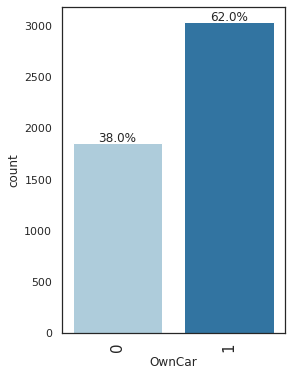

```python
labeled_barplot(tourismDf,'OwnCar', perc=True)
```

**Observations:**

62% Customers have their own cars

### Observations on NumberOfChildrenVisiting

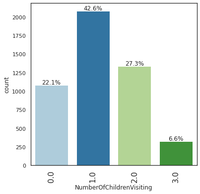

```python
labeled_barplot(tourismDf,'NumberOfChildrenVisiting', perc=True)
```

**Observations:**

### Observations on Designation

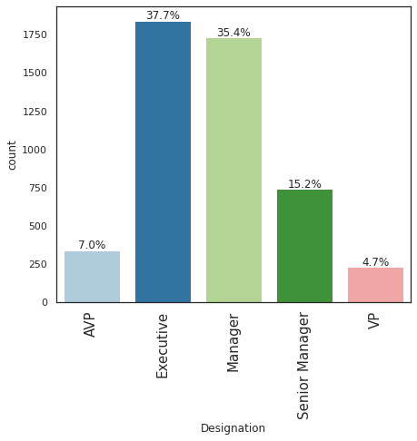

```python
labeled_barplot(tourismDf,'Designation', perc=True)
```

**Observations:**

Executive (37.7%) and Manager(35.4%) are the highest Designations of the customers in the dataset.

### Observations on MonthlyIncome

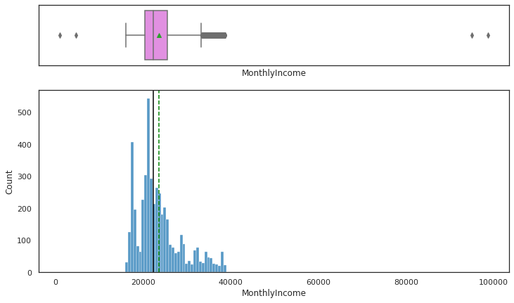

```python
histogram_boxplot(tourismDf,'MonthlyIncome')
```

**Observation:**

1. MonthlyIncome is right-skewd.
2. However, we see that the majority of customers are between income bracket 20K dollars and 30K dollars.
3. We also see two outliers in the low end and on the highest end.
4. There are several outliers after the approx 35K dollars income level.

## Bivariate and Multivariate Analysis

### Correlation Matrix

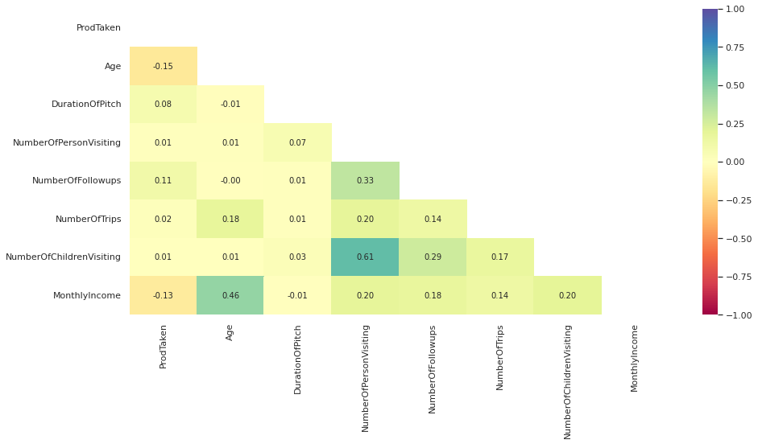

```python
plt.figure(figsize=(15, 7))
# sns.heatmap(tourismDf.corr(), annot=True, vmin=-1, vmax=1, fmt=".2f")
# plt.show()

corr= tourismDf.corr()

# Getting the Upper Triangle of the co-relation matrix
matrix = np.triu(corr)

# using the upper triangle matrix as mask
sns.heatmap(corr, annot=True,vmin=-1, vmax=1, fmt=".2f", mask=matrix, cmap='Spectral')
plt.show()
```

**Observations:**

- `ProductTaken` has a slight positive correlation with `NumberOfFollowUps` and `DurationOfPitch`
- `Age` has a strong correlation with `MonthlyIncome`
- `NumberOfPersonsVisiting` seems to have a strong correlation with `NumberOfChildrenVisiting` and `NumberOfFollowups` and slight correlation with `NumberOfTrips` and `MonthlyIncome`

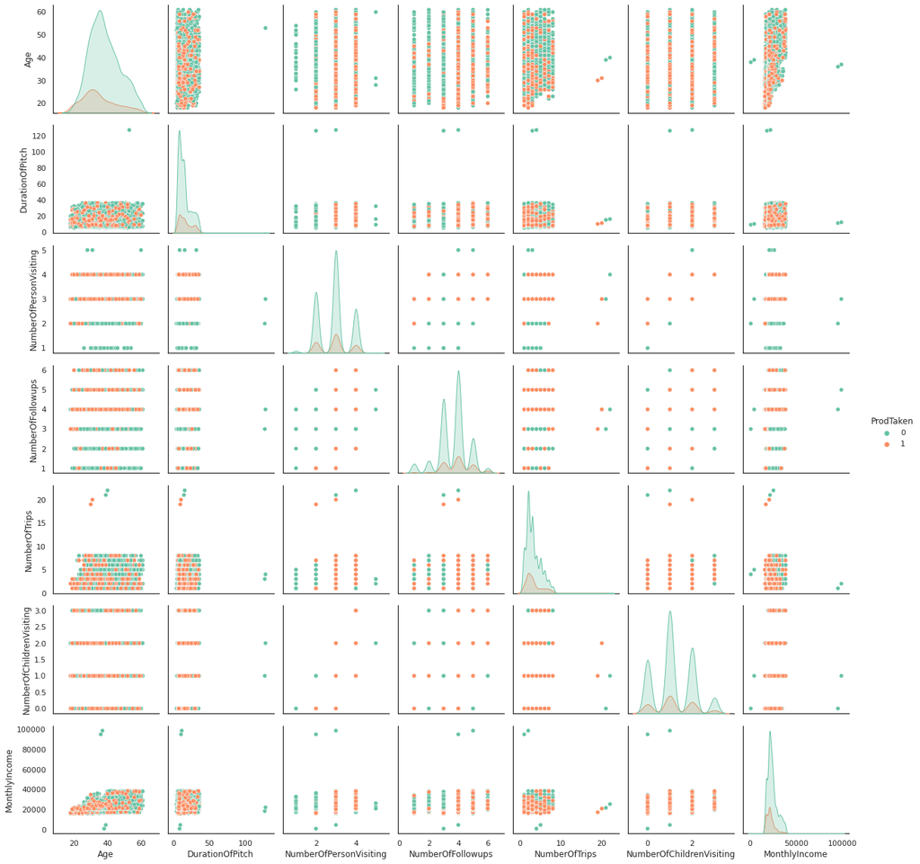

```python
sns.set_palette(sns.color_palette("Set2", 8))
sns.pairplot(tourismDf, hue="ProdTaken",corner=False)
plt.show()
```

- Data is kind of scattered.

### Functions to plot charts

```python
### function to plot distributions wrt target
def distribution_plot_wrt_target(data, predictor, target):

    fig, axs = plt.subplots(2, 2, figsize=(12, 10))

    target_uniq = data[target].unique()

    axs[0, 0].set_title("Distribution of target for target=" + str(target_uniq[0]))
    sns.histplot(
        data=data[data[target] == target_uniq[0]],
        x=predictor,
        kde=True,
        ax=axs[0, 0],
        color="teal",
        stat="density",
    )

    axs[0, 1].set_title("Distribution of target for target=" + str(target_uniq[1]))
    sns.histplot(
        data=data[data[target] == target_uniq[1]],
        x=predictor,
        kde=True,
        ax=axs[0, 1],
        color="orange",
        stat="density",
    )

    axs[1, 0].set_title("Boxplot w.r.t target")
    sns.boxplot(data=data, x=target, y=predictor, ax=axs[1, 0], palette="gist_rainbow")

    axs[1, 1].set_title("Boxplot (without outliers) w.r.t target")
    sns.boxplot(
        data=data,
        x=target,
        y=predictor,
        ax=axs[1, 1],
        showfliers=False,
        palette="gist_rainbow",
    )

    plt.tight_layout()
    plt.show()
```

```python
# function to plot stacked bar chart
def stacked_barplot(data, predictor, target):
    """
    Print the category counts and plot a stacked bar chart

    data: dataframe
    predictor: independent variable
    target: target variable
    """
    count = data[predictor].nunique()
    sorter = data[target].value_counts().index[-1]
    tab1 = pd.crosstab(data[predictor], data[target], margins=True).sort_values(
        by=sorter, ascending=False
    )
    print(tab1)
    print("-" * 120)
    tab = pd.crosstab(data[predictor], data[target], normalize="index").sort_values(
        by=sorter, ascending=False
    )
    tab.plot(kind="bar", stacked=True, figsize=(count + 5, 6))
    plt.legend(
        loc="lower left", frameon=False,
    )
    plt.legend(loc="upper left", bbox_to_anchor=(1, 1))
    plt.show()
```

### ProductTaken vs Age

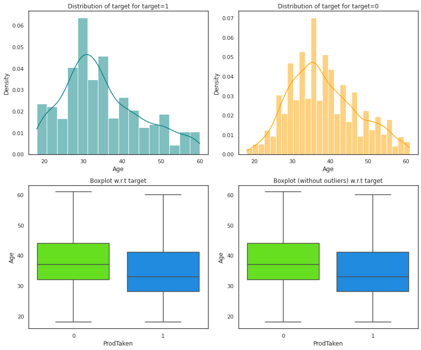

```python
distribution_plot_wrt_target(tourismDf, "Age", "ProdTaken")
```

### ProductTaken vs TypeOfContact

```
ProdTaken           0    1   All
TypeofContact
All              3946  917  4863
Self Enquiry     2837  607  3444
Company Invited  1109  310  1419
------------------------------------------------------------------------------------------------------------------------
```

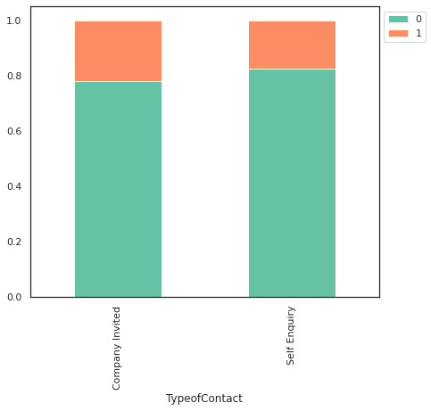

```python
stacked_barplot(tourismDf, "TypeofContact", "ProdTaken")
```

**Observations:**

### ProductTaken vs CityTier

```
ProdTaken     0    1   All
CityTier
All        3968  920  4888
1          2670  520  3190
3          1146  354  1500
2           152   46   198
------------------------------------------------------------------------------------------------------------------------
```

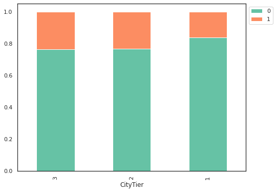

```python
stacked_barplot(tourismDf, "CityTier", "ProdTaken")
```

**Observations:**

More Customers from Tier 2 and 3 cities have purchased Travel Packages.

### ProductTaken vs DurationOfPitch

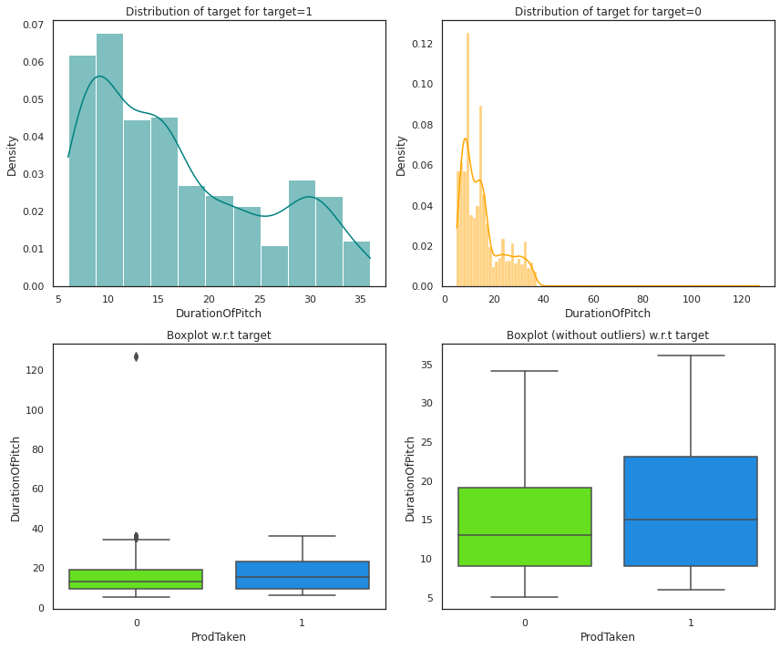

```python
distribution_plot_wrt_target(tourismDf, "DurationOfPitch", "ProdTaken")
```

**Observations:**

### ProductTaken vs Occupation

```
ProdTaken          0    1   All
Occupation
All             3968  920  4888
Salaried        1954  414  2368
Small Business  1700  384  2084
Large Business   314  120   434
Free Lancer        0    2     2
------------------------------------------------------------------------------------------------------------------------
```

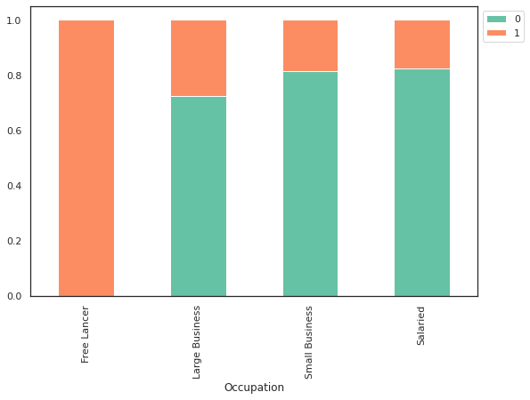

```python
stacked_barplot(tourismDf, "Occupation", "ProdTaken")
```

**Observations:**

1. Customers who are Freelancers by Occupation have bought travel packages. However the sample size is only two.
2. Of the 434 Large Business owning customers, almost 30% bought travel packages.
3. Among Salaried and Small Business owning customers,close to 20% have bought travel packages.

### ProductTaken vs Gender

```
ProdTaken     0    1   All
Gender
All        3968  920  4888
Male       2338  578  2916
Female     1630  342  1972
------------------------------------------------------------------------------------------------------------------------
```

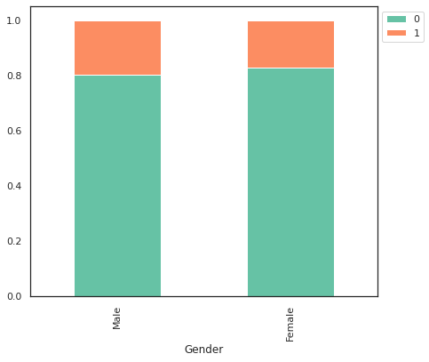

```python
stacked_barplot(tourismDf, "Gender", "ProdTaken")
```

**Observations:**

Number of Male customers are higher than Female customers, percentage of Male customers who have purchased the travel package are slightly higher than the Female customers.

### ProductTaken vs NumberOfPersonVisiting

```
ProdTaken                  0    1   All
NumberOfPersonVisiting
All                     3968  920  4888
3                       1942  460  2402
2                       1151  267  1418
4                        833  193  1026
1                         39    0    39
5                          3    0     3
------------------------------------------------------------------------------------------------------------------------
```

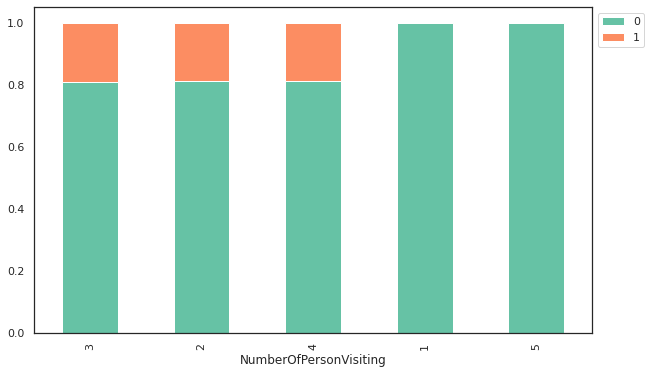

```python
stacked_barplot(tourismDf, "NumberOfPersonVisiting", "ProdTaken")
```

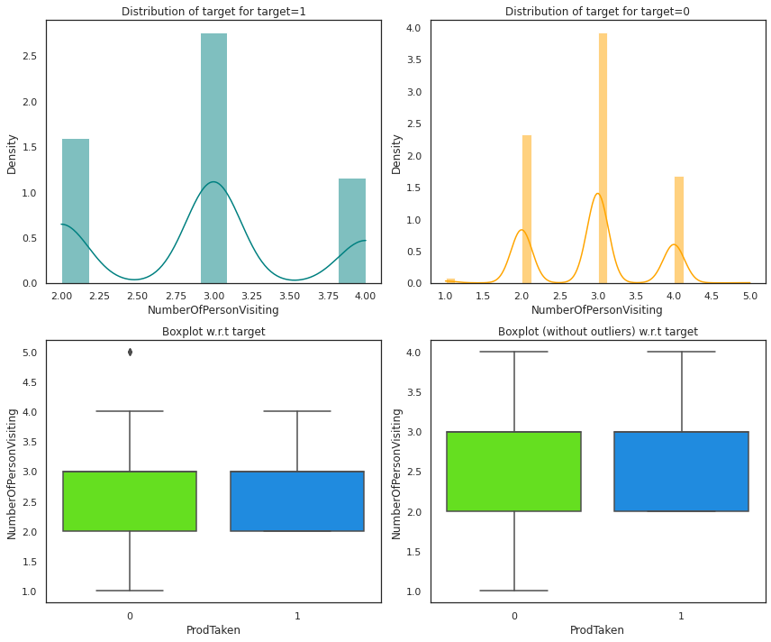

```python
distribution_plot_wrt_target(tourismDf, "NumberOfPersonVisiting", "ProdTaken")
```

There is a very minimal outlier for customers travelling in group of 5. I chose to leave it as it may not have major impact.